# DATA604 - HW1 - Distribution Simulation

Chris G Martin

August 29, 2017

# Homework One - Simulation Distribution

Generate 100 simulations of 30 samples each from a distribution (other than normal) of your choice. Graph the sampling distribution of means. Graph the sampling distribution of the minimum. Share your graphs and your R code. What did the simulation of the means demonstrate? What about the distribution of the minimum…?

```r
library(ggplot2)
```

## Simulation

To generate the samples, I decided to simple use the built-in *sample* function as it makes the process quite simple to do. This distribution is not necessarily normal.

```r
distsim <- function(quant, reps){
  #create empty objects for the means and mins
  simmeans <- c()
  simmins <- c()

  #loop the function reps number of times
  for (i in 1:reps){
    #gather a sample of numbers between 0 and 1000, quant times
    x <- sample(0:1000, quant, replace=TRUE)
    #collect the mean of the sample
    simmeans[i] <- mean(x)
    #collect the minimum of the sample
    simmins[i] <- min(x)
  }

  #save the simulation as a data frame
  simulation <- data.frame(means=simmeans, mins=simmins)
  simulation
}

sim <- distsim(30, 100)
head(sim)
```

```
##      means mins
## 1 518.1333   12
## 2 483.9667   12
## 3 543.6333   13
## 4 560.2667   24
## 5 472.7667   71
## 6 475.7333   27
```

### Distribution of Means

According to the central limit theorem (CLT), a sampling distribution approaches normality as the sample grows large.

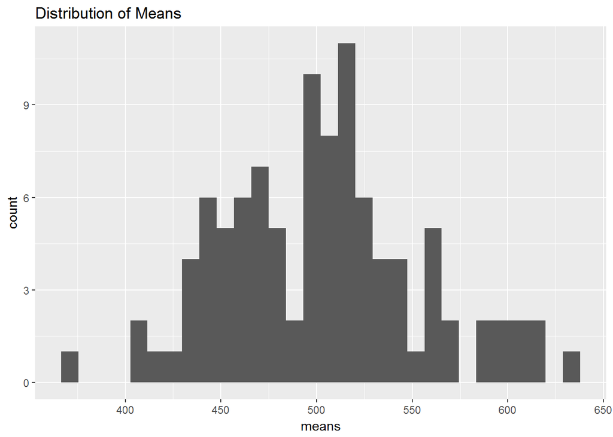

```r
ggplot(sim, aes(x=means)) + geom_histogram() + ggtitle("Distribution of Means")
```

### Distribution of Minimums

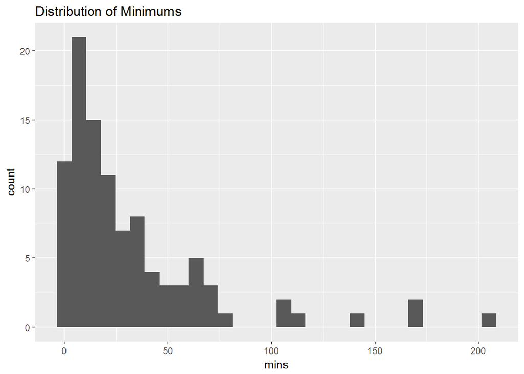

```r
ggplot(sim, aes(x=mins)) + geom_histogram() + ggtitle("Distribution of Minimums")
```

### Discussion

```r
sim <- distsim(50, 1000)
```

The CLT appears to hold:

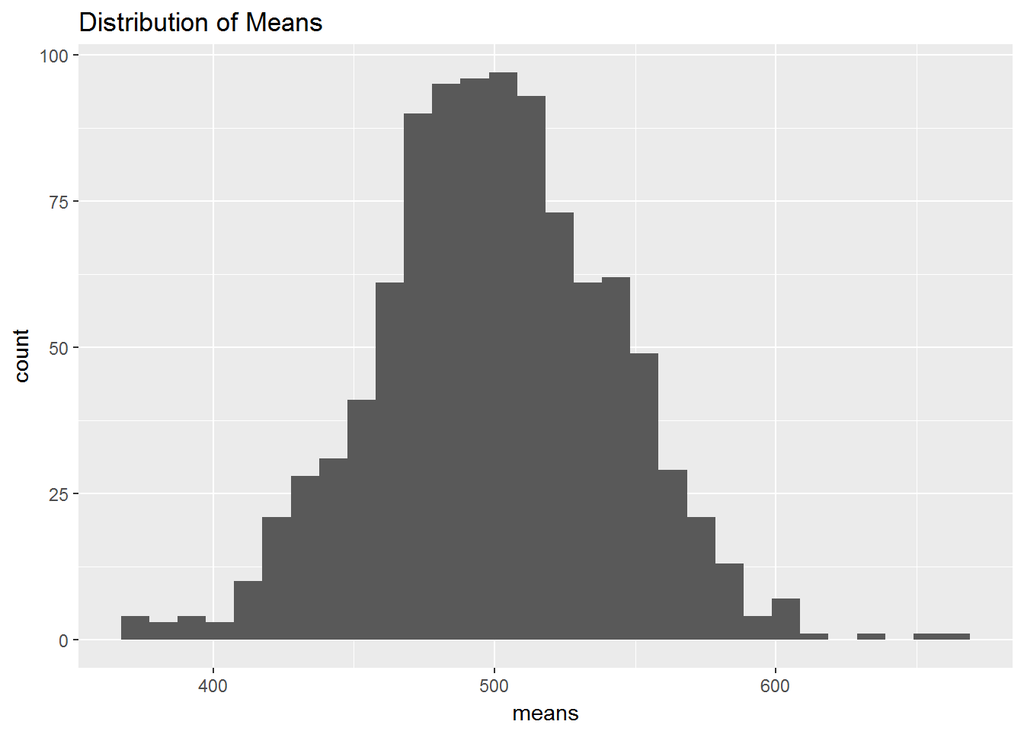

```r
ggplot(sim, aes(x=means)) + geom_histogram() + ggtitle("Distribution of Means")
```

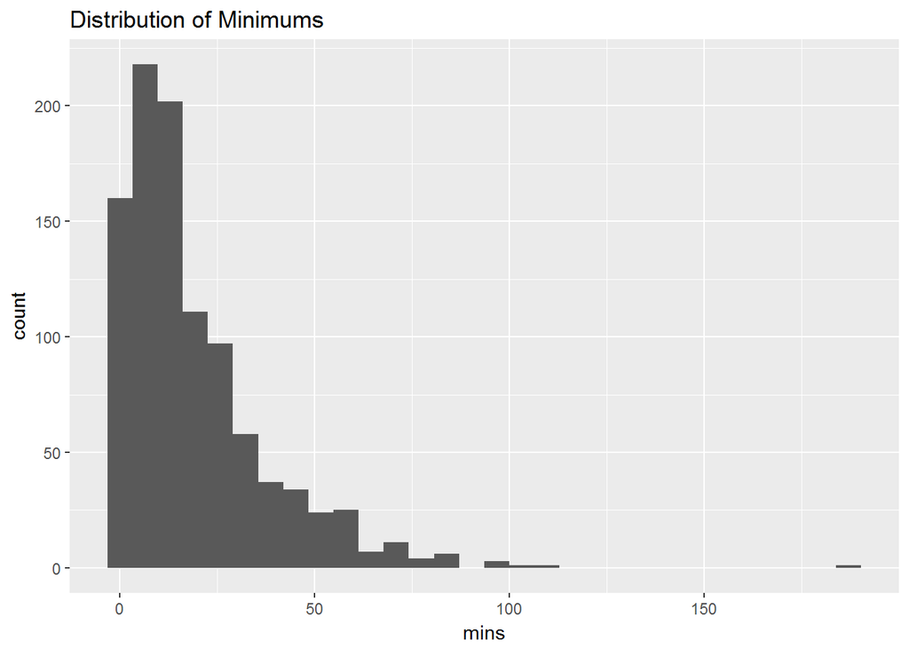

```r
ggplot(sim, aes(x=mins)) + geom_histogram() + ggtitle("Distribution of Minimums")
```

This simulation reminds me of a game (possibly a test?) where one person thinks of a number and asks the player to guess the number. Typically the player will guess regular (standard) numbers such as 1, 100, 50, 25, etc. The part that makes this game entertaining is that there are no contraints to the simlator’s number. It can be an integer (such as 1 or 100), it can be a decimal (0.242329 or 123.2930123), an imaginary number (i or n), a placeholder number (pi or infinity), or even something else (-4.2323 or the square root of 2 or 0/4). This simulation reminds me of that game, because there is always the possiblity for the number (minimum) to be different than expected so long as the constraints allow it to.

Lesson: assume that anything is possible, so long as it is possible.

Secondary lesson: simulations can help discover these ‘anything’ scenarios.